# Assignment 05 R

R. Schütz

2023-01-26

# General

Github-Projekt URL: https://github.com/Borschu/Assignment_05

Sometimes it seems that Markdown has problems outputting so much especially if changes are unsaved. (eg. regarding the graphs it states sometimes “kann png()-Gerät nicht starten”). Saving the document, Restart R, clear all output and run helped me to solve this problem.

Install / load packages:

```r
#install.packages("httr")
library("httr")

library("tidyverse")
#install.packages("magrittr")
library("magrittr")
```

```r
library("maps")
```

# Getting to know the API

Limit: 5000 API calls per day rate limit: 5 requests per second Only the 1000th item can be retrieved (size*page <1000)

```r
# read file for api key
source("C:/Users/schur/OneDrive/Dokumente/Studium/Data Science Master Tübingen/1. Semester/Data Science Project Management/Assignment/key_assignment_5.R")
```

# Interacting with the API - the basics

## (7)

```r
# search for all venues in Germany (where countryCode = DE)
res_venue_ger <- GET(url = "https://app.ticketmaster.com/discovery/v2/venues/",
                     query = list(apikey = ticketmaster_key,
                                  "countryCode" = "DE"))

# get content of the query and print it
con_venue_ger <- content(res_venue_ger)
con_venue_ger
```

```
## $`_embedded`
## $`_embedded`$venues
## $`_embedded`$venues[[1]]
## $`_embedded`$venues[[1]]$name
## [1] "Grosse Freiheit 36"
##
## $`_embedded`$venues[[1]]$type
## [1] "venue"
##
## $`_embedded`$venues[[1]]$id
## [1] "KovZpZAn6vEA"
##
## $`_embedded`$venues[[1]]$test
## [1] FALSE
##
## $`_embedded`$venues[[1]]$url
## [1] "http://www.ticketmaster.de/venue/287636"
##
## $`_embedded`$venues[[1]]$locale
## [1] "en-de"
##
## $`_embedded`$venues[[1]]$images
## $`_embedded`$venues[[1]]$images[[1]]
## $`_embedded`$venues[[1]]$images[[1]]$ratio
## [1] "16_9"
##
## $`_embedded`$venues[[1]]$images[[1]]$url
## [1] "https://s1.ticketm.net/dbimages/962v."
##
## $`_embedded`$venues[[1]]$images[[1]]$width
## [1] 205
##
## $`_embedded`$venues[[1]]$images[[1]]$height
## [1] 115
##
## $`_embedded`$venues[[1]]$images[[1]]$fallback
## [1] FALSE
##
##
##
```

[output cut: 1813 more lines]

```
##
##
##
## $page
## $page$size
## [1] 20
##
## $page$totalElements
## [1] 4745
##
## $page$totalPages
## [1] 238
##
## $page$number
## [1] 0
```

We can see different lists that are nested in each other. For each venue multiple attributes (name, type, id, test, url,…) exist. For some of the attributes a specific value is directly given (for example for name). Some of these attributes have another layer (for example location has a further layer for longitude / latitude). At the end of the printed output you an see some statistics about the request. For example that in total 238 pages or 4745 elements exist for this request. (As mentioned in the later task these 4745 elements are not all venues in Germany, because as default “locale” = “en” is set. If you change to “locale” = “*” you will get all venues (see task (9)))

## (8)

```r
## name
# get the names of the venue
name <- map_chr(con_venue_ger$`_embedded`$venues, "name")

## city
# create empty city-vector
city <- c()
# loop over all 20 venues
for (i in 1:20){
  # add name to city vector
  city <- append(city, con_venue_ger$`_embedded`$venues[[i]]$city$name)
}


## postal code
# create postal code vector (map_dbl doesnt work), default to NA -> if there is no Postal code then NA
postalCode <- as.double(map_chr(con_venue_ger$`_embedded`$venues, "postalCode", .default = NA))


## address
# create empty address vector
address <- c()
# append values via loop
# if there is no such value create NA
for (i in 1:20){
  address <- append(address, ifelse(is.null(con_venue_ger$`_embedded`$venues[[i]]$address$line1),
                                    NA, con_venue_ger$`_embedded`$venues[[i]]$address$line1))
}

## url
# create url vector
url <- map_chr(con_venue_ger$`_embedded`$venues, "url")

## longitude
# create empty longitude-vector
longitude <- c()
# loop over all 20 venues
# if the value doesn exist ->NA, else append by the specific value
for (i in 1:20){
  # add value to longitude vector
  longitude <- append(longitude, ifelse(is.null(con_venue_ger$`_embedded`$venues[[i]]$location$longitude),
                                    NA, con_venue_ger$`_embedded`$venues[[i]]$location$longitude))
}
# change datatype to double
longitude <- as.double(longitude)

## latitude
# create empty latitude-vector
latitude <- c()
# loop over all 20 venues
# if the value doesn exist ->NA, else append by the specific value
for (i in 1:20){
  # add value to longitude vector
  latitude <- append(latitude, ifelse(is.null(con_venue_ger$`_embedded`$venues[[i]]$location$latitude),
                                    NA, con_venue_ger$`_embedded`$venues[[i]]$location$latitude))
}
# change datatype to double
latitude <- as.double(latitude)

# create dataframe with vectors
venue_ger <- data.frame(name, city, postalCode,address, url, longitude, latitude)
```

# Interacting with the API - advanced

## (9)

```r
# create function to get all venues for a specific country
create_df <- function(countryCode){
  # get the first page
  # we need to set "locale" = "*" because the default is "locale" = "en", with
  # this default we get only the 4745 venues. To get all venues we need to set
  # "locale" = "*"
  page <- GET(url = "https://app.ticketmaster.com/discovery/v2/venues/",
                     query = list(apikey = ticketmaster_key,
                                  "countryCode" = countryCode,
                                  "locale" = "*"))
  # let the system sleep because of the rate limit
  Sys.sleep(0.2)
  # get content of page
  con_page <- content(page)
  # get nr. of pages and nr. of entries per page
  nr_pages <- con_page$page$totalPages
  nr_entries <- con_page$page$size

  # create empty dataframe (after the first iteration this dataframe is used for the first )
  df_all <- data.frame(name = character(),
                       city = character(),
                       postalCode = double(),
                       address = character(),
                       url = character(),
                       longitude = double(),
                       latitude = double())

  # loop over all pages
  for (p in 0:(nr_pages-1)){

    # often the API request throws an error when looping over multiple pages
    # thats why the while loop is introduced
    control <- NULL
    # while loop checks if control variable is null
    while(is.null(control)){
      # get venues for a specific contry code and specific page
      page <- GET(url = "https://app.ticketmaster.com/discovery/v2/venues/",
                     query = list(apikey = ticketmaster_key,
                                  "countryCode" = countryCode,
                                  "locale" = "*",
                                  "page" = p))
      # get content of a page
      content = content(page)
      # create controll variable
      control <- content$`_embedded`$venues
    }

    # the last page is usually not full
    # to get the number of elements on the last page this if-statement
    # is created
    if (p == nr_pages-1){
    nr_entries = con_page$page$totalElements %% nr_entries
    }

    ## name
    # get names of venues (and create a vector)
    # the .default = NA sets missings to NA
name <- map_chr(content$`_embedded`$venues, "name", .default = NA)

## city
# create empty city-vector
city <- c()
# loop over all 20 venues
for (i in 1:nr_entries){
  # add name to city vector
  city <- append(city, ifelse(is.null(content$`_embedded`$venues[[i]]$city$name),NA,
                              content$`_embedded`$venues[[i]]$city$name))
}


## postal code
# create postal code vector (map_dbl doesnt work), default to prevent error if value is missing
postalCode <- as.double(map_chr(content$`_embedded`$venues, "postalCode", .default = NA))


## address
# create empty adress vector
address <- c()
# append values via loop
# if there is no such value create NA
for (i in 1:nr_entries){
  address <- append(address, ifelse(is.null(content$`_embedded`$venues[[i]]$address$line1),
                                    NA, content$`_embedded`$venues[[i]]$address$line1))
}

## url
# create url vector
url <- map_chr(content$`_embedded`$venues, "url", .default = NA)

## longitude
# create empty longitude-vector
longitude <- c()
# loop over all 20 venues
# if the value doesn exist ->NA, else append by the specific value
for (i in 1:nr_entries){
  # add name to longitude vector
  longitude <- append(longitude, ifelse(is.null(content$`_embedded`$venues[[i]]$location$longitude),
                                    NA, content$`_embedded`$venues[[i]]$location$longitude))
}
# change datatype to double
longitude <- as.double(longitude)

## latitude
# create empty latitude-vector
latitude <- c()
# loop over all 20 venues
# if the value doesn exist ->NA, else append by the specific value
for (i in 1:nr_entries){
  # add name to longitude vector
  latitude <- append(latitude, ifelse(is.null(content$`_embedded`$venues[[i]]$location$latitude),
                                    NA, content$`_embedded`$venues[[i]]$location$latitude))
}
# change datatype to double
latitude <- as.double(latitude)


# create dataframe
df_page <- data.frame(name, city, postalCode,address, url, longitude, latitude)

# bind the dataframes together
df_all <- rbind(df_all, df_page)

# let system sleep because of the rate limit
Sys.sleep(0.2)

  }

  # return dataframe
  return(df_all)
}

# create dataframe with venues for Germany
venue_de <- create_df("DE")
# print head of dataframe
print("The first 10 rows of the dataframe: ")
```

```
## [1] "The first 10 rows of the dataframe: "
```

```r
print(head(venue_de,10))
```

```
##                        name         city postalCode               address
## 1        Grosse Freiheit 36      Hamburg      22767    Grosse Freiheit 36
## 2                 Gruenspan      Hamburg      22767    Grosse Freiheit 58
## 3         Huxleys Neue Welt       Berlin      10967  Hasenheide 107 – 113
## 4           Zentrum am Park Emmelshausen      56281 Rhein-Mosel-Straße 45
## 5  Stadthalle (Theatersaal)      Mülheim      45479 Theodor-Heuss-Platz 1
## 6             Schlossgarten     Bruchsal      76646      Schloss Bruchsal
## 7                Stadthalle   Hockenheim      68766       Rathausstraße 3
## 8                       FZW     Dortmund      44263       Ritterstraße 20
## 9               Arena Trier        Trier      54292    Fort-Worth-Platz 1
## 10            Eissporthalle    Memmingen      87700   Hühnerbergstraße 19
##                                                                                         url
## 1                                                   http://www.ticketmaster.de/venue/287636
## 2                                                   http://www.ticketmaster.de/venue/287155
## 3                                                   http://www.ticketmaster.de/venue/286842
```

[output cut: 18 more lines]

```r
# print dimension of the dataframe
print("Dimensions of the dataframe: ")
```

```
## [1] "Dimensions of the dataframe: "
```

```r
print(dim(venue_de))
```

```
## [1] 12932     7
```

# Visualizing the extracted data

## (10)

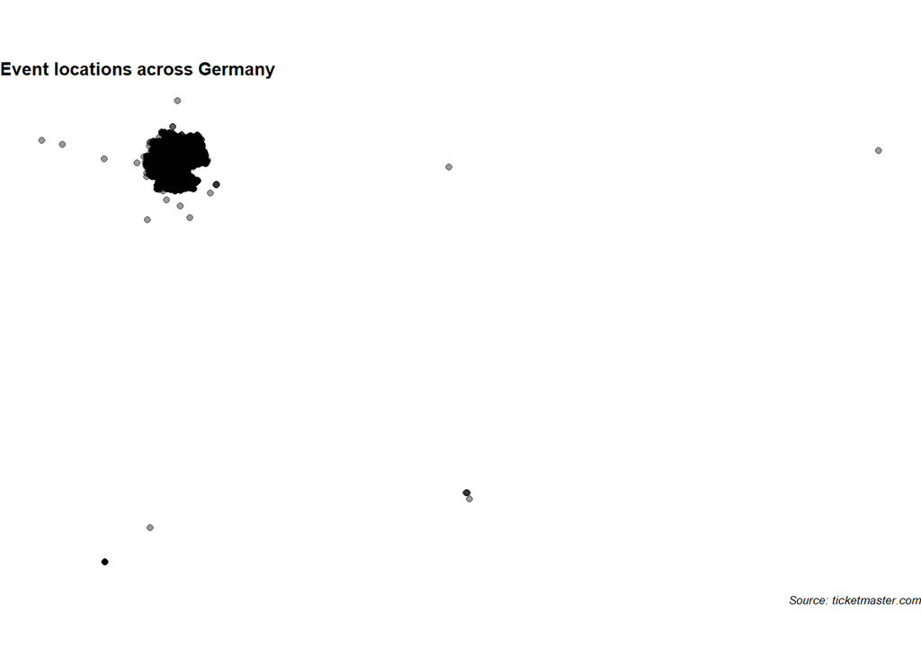

```r
# based on the code that is mentioned in the assignment the venues are visualized
ggplot(venue_de) +
borders("world", "Germany", colour = "black", fill = "grey90") +
  # add geom_point to create points for the locations
  # add alpha to make points transparent (-> to make overlaying points visible)
  geom_point(aes(longitude,latitude),
             alpha = 0.4)+
theme_void() +
coord_quickmap() +
labs(title = "Event locations across Germany",
caption = "Source: ticketmaster.com") +
theme(title = element_text(size=8, face='bold'),
plot.caption = element_text(face = "italic"))
```

## (11)

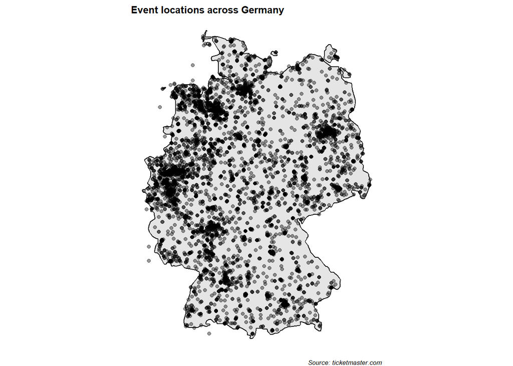

```r
# create NAs for latitude / longitude if  outside from germany
# write a function to make life easier for the next tasks

adapt_long_lat <- function(df_country,long_lower,long_upper,lat_lower,lat_upper){
  # change the values to NA for long / lat if the values are outside the long/lat
  # range
  df_country$longitude[df_country$longitude < long_lower] <- NA
  df_country$longitude[df_country$longitude > long_upper] <- NA
  df_country$latitude[df_country$latitude < lat_lower] <- NA
  df_country$latitude[df_country$latitude > lat_upper] <- NA

    return(df_country)
}

#longitude is outside the range (5.866, 15.042) or
#where the value of latitude is outside the range (47.270, 55.059)
venue_de_adjust <- adapt_long_lat(venue_de,5.866, 15.042,47.270, 55.059)

# visualize venues with adapted longitude /latitude
ggplot(venue_de_adjust) +
borders("world", "Germany", colour = "black", fill = "grey90") +
  # add geom_point to create points for the locations
  # add alpha to make points transparent (-> to make overlaying points visible)
  geom_point(aes(longitude,latitude),
             alpha = 0.4)+
theme_void() +
coord_quickmap() +
labs(title = "Event locations across Germany",
caption = "Source: ticketmaster.com") +
theme(title = element_text(size=8, face='bold'),
plot.caption = element_text(face = "italic"))
```

# Event locations in other countries

## (12)

In this task the venues for Italy will be examined.

```r
# Create dataframe with venues in italy
venue_it <- create_df("IT")
# print head of dataframe
print("The first 10 rows of the dataframe: ")
```

```
## [1] "The first 10 rows of the dataframe: "
```

```r
print(head(venue_it,10))
```

```
##                           name            city postalCode
## 1                    Live Club           Milan      20056
## 2                        ITALY Gardone Riviera      25083
## 3                        ITALY          Rubano      35030
## 4                        ITALY            Rome        187
## 5                        ITALY          Modena      41121
## 6                        ITALY          Rivoli      10098
## 7  Teatro Nazionale CheBanca!           Milano      20149
## 8                Visarno Arena        Florence      50144
## 9                   Stadthalle           Bozen      39100
## 10             Arena di Verona          Verona      37121
##                                     address
## 1                  Via Giuseppe Mazzini, 58
## 2                     Corso Zanardelli, 196
## 3         via Liguria 1  Sarmeola di Rubano
```

[output cut: 29 more lines]

```r
# print dimension of the dataframe
print("Dimensions of the dataframe: ")
```

```
## [1] "Dimensions of the dataframe: "
```

```r
print(dim(venue_it))
```

```
## [1] 297   7
```

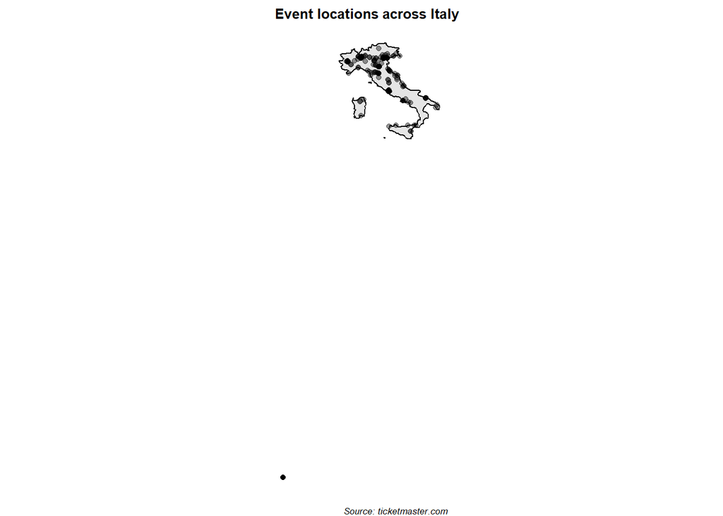

```r
# visualize the venues
ggplot(venue_it) +
borders("world", "Italy", colour = "black", fill = "grey90") +
  # add geom_point to create points for the locations
  # add alpha to make points transparent (-> to make overlaying points visible)
  geom_point(aes(longitude,latitude),
             alpha = 0.4)+
theme_void() +
coord_quickmap() +
labs(title = "Event locations across Italy",
caption = "Source: ticketmaster.com") +
theme(title = element_text(size=8, face='bold'),
plot.caption = element_text(face = "italic"))
```

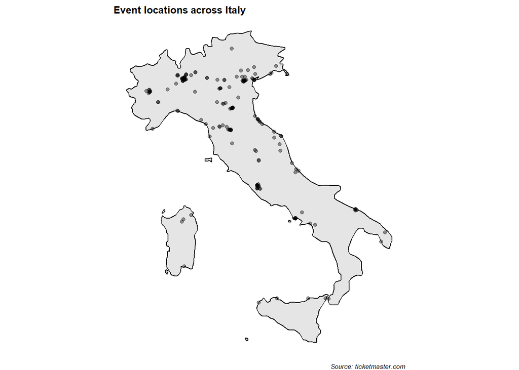

```r
# adjust the longitude / latitude column based on the latitude / longitude range
# NAs if outside the latitude / longitude range
venue_it_adjust <- adapt_long_lat(venue_it,6.616667, 18.516667, 37.933333, 47.083333)


# visualize venues with adjusted longitude / latitude
ggplot(venue_it_adjust) +
borders("world", "Italy", colour = "black", fill = "grey90") +
  # add geom_point to create points for the locations
  # add alpha to make points transparent (-> to make overlaying points visible)
  geom_point(aes(longitude,latitude),
             alpha = 0.4)+
theme_void() +
coord_quickmap() +
labs(title = "Event locations across Italy",
caption = "Source: ticketmaster.com") +
theme(title = element_text(size=8, face='bold'),
plot.caption = element_text(face = "italic"))
```